# **IA 717: CHAI & fairness: linguistics of AI ethics charters & manifestos**

## **3.2 TXT : ''Fairness'' in the data**

### 2.1 QUESTION 2.1

2.1 Question: which are the documents in which the word "fairness" appears the most (top 10% of the corpus)? Please provide a visualization and comment it.

2.1 Answer:

```python
model = 'TXT_STUDENT'
data = list_corpus['txt']

nb_fairness_by_file = {}
for filename in data.data:
    data_file = data.data[filename]
    nb_fairness_by_file[filename] = 0
    for word in data_file.split():
        if word == 'fairness' :
            nb_fairness_by_file[filename] += 1

#Liste du top des fichiers qui ont le plus de fairness
top_fairness = sorted(nb_fairness_by_file.items(),key =lambda x : x[1], reverse = True) #Liste des mots les plus utilisés
```

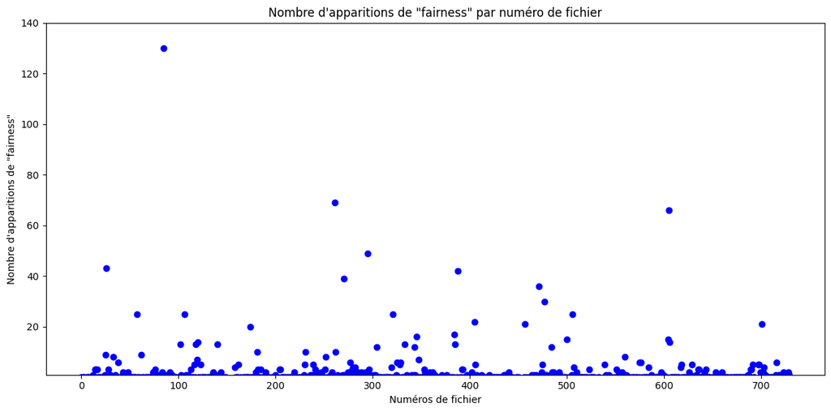

```python
fichiers = [int(x[0].split('.')[0]) for x in top_fairness]  # Extraire les numéros de fichiers
valeurs = [x[1] for x in top_fairness]

# Créer un plot avec les numéros de fichiers sur l'axe X
plt.close('all')
fig = plt.figure(figsize=(12, 6))
ax = fig.add_subplot()
ax.scatter(fichiers, valeurs, marker='o', linestyle='-', color='b')
ax.set_xlabel('Numéros de fichier')
ax.set_ylabel('Nombre d\'apparitions de "fairness"')
ax.set_title('Nombre d\'apparitions de "fairness" par numéro de fichier')
ax.set_ylim(1, max(valeurs) + 10)  # Fixer les limites de Y pour qu'il commence à 1
fig.tight_layout()
plt.show()
```

On remarque que seuls 256 documents ont le mot fairness dedans

Rq : regarder aussi le mot unfairness et un-fairness (on associe ces 2 mots en 1 seul )

On va perdre les titres, les références par ex. de schéma, bref les infos en dehors du texte

## **3.3 TXT : Fairness, N-gram**

Nous nous interessons uniquement au 2-gram et 3-gram.

```python
# Vectorisation pour 1-grams, 2-grams, et 3-grams, avec stopwords
def get_ngrams_freqs(corpus_clean, stop_words, ngram = (2, 3)):
    if not corpus_clean.strip():
        raise ValueError("Le corpus est vide. Impossible de générer des n-grams.")

    vectorizer = CountVectorizer(ngram_range=ngram, stop_words=stop_words)
    X = vectorizer.fit_transform([corpus_clean])

    if len(vectorizer.vocabulary_) == 0:
        raise ValueError("Si vocabulaire vide, peut-être que le corpus contient uniquement des stopwords.")

    ngrams = vectorizer.get_feature_names_out()
    freqs = np.asarray(X.sum(axis=0)).ravel()
    vocab = vectorizer.vocabulary_
    return ngrams, freqs, vocab


def get_ngram_on_word(ngrams, freqs, vocab, word = "fairness"):
    '''
    It returns a dictionnaire.
    '''
    fairness_ngrams = [ngram for ngram in ngrams if word in ngram]
    fairness_ngram_counts = {fairness_ngrams[i]: freqs[vocab[fairness_ngrams[i]]] for i in range(len(fairness_ngrams))}
    #print(f"frequence associées {freqs}")
    return dict(sorted(fairness_ngram_counts.items(), key=lambda item: item[1], reverse=True))


# Générer le nuage de mots
def word_cloud(fairness_ngram):
    wordcloud = WordCloud(
        width=800,
        height=400,
        background_color="white",
        colormap="viridis"
    ).generate_from_frequencies(fairness_ngram)

    # Afficher le nuage de mots
    plt.figure(figsize=(10, 5))
    plt.imshow(wordcloud, interpolation='bilinear')
    plt.axis("off")
    plt.show()
```

```python
# Les stopwords utilisés ici sont ceux après la réflexion
stop_words = ['the','of','to','in','a','for','is','that','on','be','are','de','by','an','this','it','will','which','la','their','at','et','also','in','such','des','this']

# on récupère les bi et tri grams
corpus_bi_tri_ngram, corpus_bi_tri_freqs, corpus_bi_tri_vocab = get_ngrams_freqs(corpus_clean, stop_words)

# on récupère ceux associés à fairness. Attention pour utiliser un autre terme simplement rappeler get_ngram_on_word
fairness_ngram = get_ngram_on_word(corpus_bi_tri_ngram, corpus_bi_tri_freqs, corpus_bi_tri_vocab)
```

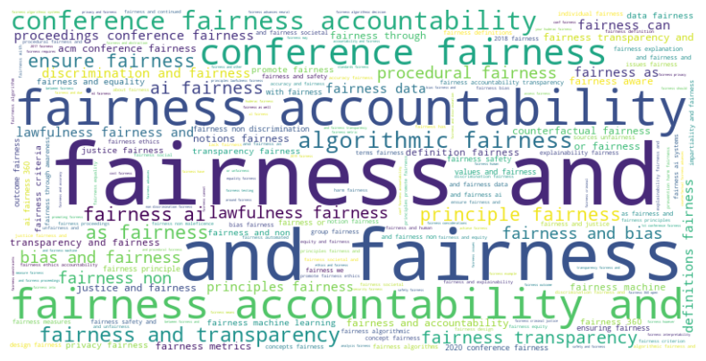

```python
word_cloud(fairness_ngram)
```

## **3.4 TXT : Fairness, POS-tag**

```python
def clean_data_for_pos(data):
    """
    Nettoie les données pour le POS tagging tout en conservant l'ordre d'origine.

    Returns: list[str]: Liste des documents nettoyés dans l'ordre des valeurs du dictionnaire.
    """
    cleaned_documents = []

    for key, line in data.items():
        newline = []
        for word in line.split(" "):
            # Conserve les mots alphanumériques avec ponctuation utile
            if re.match(r'^[a-zA-Z0-9]+([\'\-\.][a-zA-Z0-9]+)?$', word) or re.match(r'^[\.\,\!\?]$', word):
                # Supprime les mots à 1 caractère inutiles, sauf ponctuation utile ou mots spécifiques
                if len(word) > 1 or word in ['a', 'I', '.', ',', '!', '?']:
                    newline.append(word)
        # Reconstruit le document nettoyé
        cleaned_documents.append(" ".join(newline))

    return cleaned_documents
```

```python
# Le vocabulaire utilisé ici ne sont pas les tokens
dict_data = list_corpus['txt'].data #data dict[str, str]: pour chaque fichier (clés = nom de fichier), son contenu

list_data_pos = clean_data_for_pos(dict_data)

# Charger le modèle de langue anglais de spaCy
nlp = spacy.load("en_core_web_sm")
#Traiter en parallèle chaque document pour qu'il fasse nlp(doc) ce qui correspond au POS tagging
batch_size = 40
corpus_POS = list(nlp.pipe(list_data_pos, batch_size=batch_size))

# 20min
```

```python
# Dictionnaire pour stocker les rôles de "fairness" et leur fréquence
fairness_roles = defaultdict(int)

# Parcourir chaque document pour trouver les occurrences de "fairness"
for doc in corpus_POS:
    for token in doc:
        if token.text.lower() == "fairness":
            # Compter chaque rôle grammatical de "fairness"
            fairness_roles[token.dep_] += 1

# Convertir le defaultdict en dictionnaire classique pour affichage
fairness_roles = dict(fairness_roles)
# pprint(fairness_roles)
print(tabulate(dict_revert(tmp, sort=True), headers=['Rôle grammatical', 'Nb occurence'], tablefmt='pipe'))
```

[output not shown]

## Pour aller plus loin et pour faire les commentaires et explicationss :

### Axes de réflexion :

- Possible de chercher les synonymes du mot :
  - synonymes : bias, justice, unbiased, impartiality, objectivity, balance, honesty, neutrality, equity
- Possible de chercher les traductions du mot dans les langues des docs
- Possible de fusionner les variances d'un mot (pluriel, )

### Analyse manuelle pour déterminer les stop-words :

**LISTE des nouveaux stopword et de notre réflexion**

```
stop_words = ['the','and','of','to','in','a','for','is','that','on','be','are','or','de','by','an','this','it','will','which','la','their','at','et','also','in','such','des','this']
```

**Méthode :**

- Lister sur un corpus non nettoyé ou speudo-nettoyé sans retirer les stop-word ni les mots les plus fréquent
- Pour chacun :
  - déterminer si cela reste un stop-word à retirer
  - retirer les vraies mots comme IA ou data
  - confirmer le retrait des caractères non alphabétique
  - confirmer le retrait des tokens à une lettre
  - on garde les auxiliaires et les négations afin de garder le context de l'utilisation du mot

Première passe :

- the :X
- and : X
- of : X
- to : X
- in : X
- a : X
- for : X
- AI : on garde
- is : X
- that : X
- on : X
- be : X
- as : X
- are : X
- The : X
- or : X
- e : X
- de : X
- data : on garde
- with : X
- by : X
- \u200b : X
- t : X
- an : X
- Non alpha-numérique : X
- o : X
- s : X
- Tous les mots d’une lettre : X
- can : on garde
- from : X
- this : X
- not : on garde
- it : X
- will : X
- which : X
- have : on garde
- la : X
- their : X
- use : X
- at : X
- should : X
- et : X
- also : X
- In : X
- such : X
- des : X
- has : on garde
- systems : on garde
- more : on garde
- public : on garde
- this : X
- human : on garde
- may : on garde

On remarque que les mots les plus utilisés sont des stopwords, on va devoir choisir lesquels on enlève et lesquels on garde, car, par exemple, on ne veut pas effacer la négation. Je mets X quand j’enlève le mot Comment on choisit : en fonction du gain de sens apporté on le juge utile ou non (par ex. on garde les négations, les comparaisons, superlatifs, mot-clé)

Il faudra enlever les stop-words and et or car en vérité ils sont significatifs (montrent que fairness est utilisé dans un contexte décoratif) pour étudier la fréquence des mots mais reste important pour une analyse syntaxique linguistique.

## **3.5 TXT : Fairness, élargissement vocabulaire**

Focus uniquement la corrélation entre fairness et justice, et, fairness et bias.

=>PS : voir le rapport